# Project: Investigate The TMDB Movies Dataset

- Introduction
- Data Wrangling
- Exploratory Data Analysis
- Conclusions

## Introduction

#### For this Work i will be working with **The Movie Data (TMDb)**, This data set contains information about 10,000+ movies collected from The Movie Database (TMDb) from [Kaggle](https://www.google.com/url?q=https://www.kaggle.com/tmdb/tmdb-movie-metadata&sa=D&ust=1532469042115000) including user ratings and revenue.

#### In this part i will import the necessary packages i will use to investigate the data set

```python
#importing the packages that we will use

import pandas as pd
import numpy as np
import matplotlib.pyplot as plt
%matplotlib inline
```

## Data Wrangling

In this part i will have a first look in my datas, check for cleanliness and clean my dataset for further analysis.

### General Properties

```python
#Loading the data in the "df" dataframe and visualising some entries

df = pd.read_csv("tmdb-movies.csv")
```

```python
# we define a function that will help us make a summary of the dataframe

def summary(dataframe):

    #Here we display an overview of the data set
    print("Overview of the dataframe :")
    display(dataframe.head())

    #Here we display the dimensions of our datas
    print("\n Dimensions : \n")
    display(dataframe.shape)

    #Here we check missing values
    print("\n Missing values resume : \n")
    display(dataframe.isna().sum())

    #We check for duplicated rows
    print("\n Number of duplicated rows: \n")
    display(dataframe.duplicated().value_counts())

    #Resume of columns and their data type
    print("\n Columns informations:  \n")
    display(dataframe.info())

    #Some statistics from our data set
    print("\n Some Stats : \n")
    display(dataframe.describe())

    #checking uniques values for each column in the dataset
    print("\n Unique values for each Column : \n")
    display(dataframe.nunique())
```

```python
# displaying the summary of our dataframe

summary(df);
```

```
Overview of the dataframe :
```

|  | id | imdb_id | popularity | budget | revenue | original_title | cast | homepage | director | tagline | ... | overview | runtime | genres | production_companies | release_date | vote_count | vote_average | release_year | budget_adj | revenue_adj |
| --- | --- | --- | --- | --- | --- | --- | --- | --- | --- | --- | --- | --- | --- | --- | --- | --- | --- | --- | --- | --- | --- |
| 0 | 135397 | tt0369610 | 32.985763 | 150000000 | 1513528810 | Jurassic World | Chris Pratt\|Bryce Dallas Howard\|Irrfan Khan\|Vi... | http://www.jurassicworld.com/ | Colin Trevorrow | The park is open. | ... | Twenty-two years after the events of Jurassic ... | 124 | Action\|Adventure\|Science Fiction\|Thriller | Universal Studios\|Amblin Entertainment\|Legenda... | 6/9/15 | 5562 | 6.5 | 2015 | 1.379999e+08 | 1.392446e+09 |
| 1 | 76341 | tt1392190 | 28.419936 | 150000000 | 378436354 | Mad Max: Fury Road | Tom Hardy\|Charlize Theron\|Hugh Keays-Byrne\|Nic... | http://www.madmaxmovie.com/ | George Miller | What a Lovely Day. | ... | An apocalyptic story set in the furthest reach... | 120 | Action\|Adventure\|Science Fiction\|Thriller | Village Roadshow Pictures\|Kennedy Miller Produ... | 5/13/15 | 6185 | 7.1 | 2015 | 1.379999e+08 | 3.481613e+08 |
| 2 | 262500 | tt2908446 | 13.112507 | 110000000 | 295238201 | Insurgent | Shailene Woodley\|Theo James\|Kate Winslet\|Ansel... | http://www.thedivergentseries.movie/#insurgent | Robert Schwentke | One Choice Can Destroy You | ... | Beatrice Prior must confront her inner demons ... | 119 | Adventure\|Science Fiction\|Thriller | Summit Entertainment\|Mandeville Films\|Red Wago... | 3/18/15 | 2480 | 6.3 | 2015 | 1.012000e+08 | 2.716190e+08 |
| 3 | 140607 | tt2488496 | 11.173104 | 200000000 | 2068178225 | Star Wars: The Force Awakens | Harrison Ford\|Mark Hamill\|Carrie Fisher\|Adam D... | http://www.starwars.com/films/star-wars-episod... | J.J. Abrams | Every generation has a story. | ... | Thirty years after defeating the Galactic Empi... | 136 | Action\|Adventure\|Science Fiction\|Fantasy | Lucasfilm\|Truenorth Productions\|Bad Robot | 12/15/15 | 5292 | 7.5 | 2015 | 1.839999e+08 | 1.902723e+09 |
| 4 | 168259 | tt2820852 | 9.335014 | 190000000 | 1506249360 | Furious 7 | Vin Diesel\|Paul Walker\|Jason Statham\|Michelle ... | http://www.furious7.com/ | James Wan | Vengeance Hits Home | ... | Deckard Shaw seeks revenge against Dominic Tor... | 137 | Action\|Crime\|Thriller | Universal Pictures\|Original Film\|Media Rights ... | 4/1/15 | 2947 | 7.3 | 2015 | 1.747999e+08 | 1.385749e+09 |

5 rows × 21 columns

```
 Dimensions :
```

```
(10866, 21)
```

```
 Missing values resume :
```

```
id                         0
imdb_id                   10
popularity                 0
budget                     0
revenue                    0
original_title             0
cast                      76
homepage                7930
director                  44
tagline                 2824
keywords                1493
overview                   4
runtime                    0
genres                    23
production_companies    1030
release_date               0
vote_count                 0
vote_average               0
release_year               0
budget_adj                 0
revenue_adj                0
dtype: int64
```

```
 Number of duplicated rows:
```

```
False    10865
True         1
dtype: int64
```

```
 Columns informations:

<class 'pandas.core.frame.DataFrame'>
RangeIndex: 10866 entries, 0 to 10865
Data columns (total 21 columns):
 #   Column                Non-Null Count  Dtype
---  ------                --------------  -----
 0   id                    10866 non-null  int64
 1   imdb_id               10856 non-null  object
 2   popularity            10866 non-null  float64
 3   budget                10866 non-null  int64
 4   revenue               10866 non-null  int64
 5   original_title        10866 non-null  object
 6   cast                  10790 non-null  object
 7   homepage              2936 non-null   object
 8   director              10822 non-null  object
 9   tagline               8042 non-null   object
 10  keywords              9373 non-null   object
 11  overview              10862 non-null  object
 12  runtime               10866 non-null  int64
 13  genres                10843 non-null  object
 14  production_companies  9836 non-null   object
 15  release_date          10866 non-null  object
 16  vote_count            10866 non-null  int64
 17  vote_average          10866 non-null  float64
 18  release_year          10866 non-null  int64
 19  budget_adj            10866 non-null  float64
 20  revenue_adj           10866 non-null  float64
dtypes: float64(4), int64(6), object(11)
memory usage: 1.7+ MB
```

```
None
```

```
 Some Stats :
```

|  | id | popularity | budget | revenue | runtime | vote_count | vote_average | release_year | budget_adj | revenue_adj |
| --- | --- | --- | --- | --- | --- | --- | --- | --- | --- | --- |
| count | 10866.000000 | 10866.000000 | 1.086600e+04 | 1.086600e+04 | 10866.000000 | 10866.000000 | 10866.000000 | 10866.000000 | 1.086600e+04 | 1.086600e+04 |
| mean | 66064.177434 | 0.646441 | 1.462570e+07 | 3.982332e+07 | 102.070863 | 217.389748 | 5.974922 | 2001.322658 | 1.755104e+07 | 5.136436e+07 |
| std | 92130.136561 | 1.000185 | 3.091321e+07 | 1.170035e+08 | 31.381405 | 575.619058 | 0.935142 | 12.812941 | 3.430616e+07 | 1.446325e+08 |
| min | 5.000000 | 0.000065 | 0.000000e+00 | 0.000000e+00 | 0.000000 | 10.000000 | 1.500000 | 1960.000000 | 0.000000e+00 | 0.000000e+00 |
| 25% | 10596.250000 | 0.207583 | 0.000000e+00 | 0.000000e+00 | 90.000000 | 17.000000 | 5.400000 | 1995.000000 | 0.000000e+00 | 0.000000e+00 |
| 50% | 20669.000000 | 0.383856 | 0.000000e+00 | 0.000000e+00 | 99.000000 | 38.000000 | 6.000000 | 2006.000000 | 0.000000e+00 | 0.000000e+00 |
| 75% | 75610.000000 | 0.713817 | 1.500000e+07 | 2.400000e+07 | 111.000000 | 145.750000 | 6.600000 | 2011.000000 | 2.085325e+07 | 3.369710e+07 |
| max | 417859.000000 | 32.985763 | 4.250000e+08 | 2.781506e+09 | 900.000000 | 9767.000000 | 9.200000 | 2015.000000 | 4.250000e+08 | 2.827124e+09 |

```
 Unique values for each Column :
```

```
id                      10865
imdb_id                 10855
popularity              10814
budget                    557
revenue                  4702
original_title          10571
cast                    10719
homepage                 2896
director                 5067
tagline                  7997
keywords                 8804
overview                10847
runtime                   247
genres                   2039
production_companies     7445
release_date             5909
vote_count               1289
vote_average               72
release_year               56
budget_adj               2614
revenue_adj              4840
dtype: int64
```

### Questions

#### 1- What kinds of properties are associated with movies that have high revenues?

#### 2 - How much the production of a high revenue movie cost in 2015?

#### 3 - What are the 10 most profitable movies of all times?

### Data Cleaning

#### To answer those questions there are the steps we fill follow:

> **Drop the duplicate row** we have found earlier just to make our investigation more accurate

> **Create a new column 'profit'** containing the profits made by each movie **

> **Create Visuals** to enforce our analysis

> **Communicate our Findings**

```python
# here we drop unnecessary (for our questions) columns

df1= df.drop(["id", "imdb_id","homepage","tagline","keywords"], axis=1)
df1.shape
```

```
(10866, 16)
```

```python
# Here we create our new column that will contains benefits gains by each movie

df1["profit"] = df1.revenue - df1.budget
df1.shape
```

```
(10866, 17)
```

```python
# Here we drop the duplicate row we found earlier

df1.drop_duplicates(inplace=True)
```

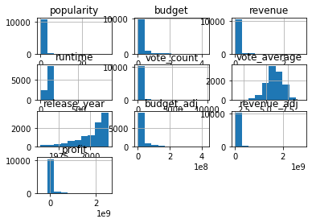

```python
# checking data repartitions for some columns with their histograms

df1.hist();
```

## Exploratory Data Analysis

> In this section we will answer to our questions

### 1- What kinds of properties are associated with movies that have high revenues?

```python
# Here we create a new dataframe with movies that have a revenue > to the revenue mean

high_revenues= df1[df1.revenue> df1.revenue.mean()]
```

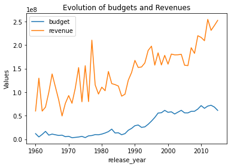

```python
# Here we have the evolution of the mean of budget and revenue by year

high_revenues.groupby(["release_year"])[['budget','revenue']].mean().plot(kind="line", ylabel="Values", title="Evolution of budgets and Revenues");
```

```python
# Here we have a resume of some features of high revenues movies

high_revenues.describe()
```

|  | popularity | budget | revenue | runtime | vote_count | vote_average | release_year | budget_adj | revenue_adj | profit |
| --- | --- | --- | --- | --- | --- | --- | --- | --- | --- | --- |
| count | 2170.000000 | 2.170000e+03 | 2.170000e+03 | 2170.000000 | 2170.000000 | 2170.000000 | 2170.000000 | 2.170000e+03 | 2.170000e+03 | 2.170000e+03 |
| mean | 1.624455 | 5.201618e+07 | 1.837673e+08 | 112.658986 | 814.637788 | 6.288940 | 2001.864977 | 5.999692e+07 | 2.319655e+08 | 1.317511e+08 |
| std | 1.783858 | 4.860556e+07 | 2.058310e+08 | 23.948073 | 1060.156325 | 0.734186 | 10.683412 | 5.039617e+07 | 2.506688e+08 | 1.786279e+08 |
| min | 0.010335 | 0.000000e+00 | 3.984634e+07 | 44.000000 | 10.000000 | 3.400000 | 1960.000000 | 0.000000e+00 | 3.693575e+07 | -1.657101e+08 |
| 25% | 0.737386 | 1.800000e+07 | 6.621655e+07 | 98.000000 | 192.000000 | 5.800000 | 1996.000000 | 2.403643e+07 | 8.358739e+07 | 3.946422e+07 |
| 50% | 1.161793 | 3.800000e+07 | 1.130136e+08 | 109.000000 | 422.000000 | 6.300000 | 2004.000000 | 4.613755e+07 | 1.457531e+08 | 7.449099e+07 |
| 75% | 1.888625 | 7.000000e+07 | 2.139479e+08 | 123.000000 | 970.750000 | 6.800000 | 2010.000000 | 8.297469e+07 | 2.773028e+08 | 1.530703e+08 |
| max | 32.985763 | 3.800000e+08 | 2.781506e+09 | 705.000000 | 9767.000000 | 8.300000 | 2015.000000 | 3.683713e+08 | 2.827124e+09 | 2.544506e+09 |

### 2 - How much the production of a high revenue movie cost in 2015?

```python
# Here we create a dataframe of high revenues movies released in 2015

df15= high_revenues[high_revenues["release_year"]==2015]
df15.shape
```

```
(102, 17)
```

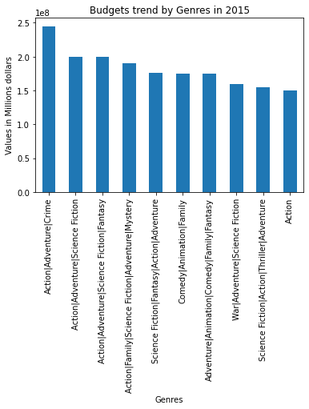

```python
# Here we visualize the mean budget of high movies in 2015 by genres

df15.groupby("genres").mean().sort_values(by="budget", ascending=False).head(10)["budget"].plot(kind="bar");
plt.title("Budgets trend by Genres in 2015")
plt.xlabel("Genres")
plt.ylabel("Values in Millions dollars")
plt.show()
```

```python
# Here we have some statistics of 2015 high revenues movies

df15.describe()["budget"]
```

```
count    1.020000e+02
mean     6.130490e+07
std      6.006325e+07
min      0.000000e+00
25%      1.575000e+07
50%      3.500000e+07
75%      8.950000e+07
max      2.800000e+08
Name: budget, dtype: float64
```

#### 3 - What are the 10 most profitable movies of all times?

```python
# Here we define a new dataframe for all time movies that made higher benefices

profitable_movies = df1.query('profit >= profit.mean()').sort_values(by='profit', ascending=False)
```

```python
# Here we have the list of top ten all time movies that made higher benefices

profitable_movies.head(10)[["original_title","release_year"]]
```

|  | original_title | release_year |
| --- | --- | --- |
| 1386 | Avatar | 2009 |
| 3 | Star Wars: The Force Awakens | 2015 |
| 5231 | Titanic | 1997 |
| 0 | Jurassic World | 2015 |
| 4 | Furious 7 | 2015 |
| 4361 | The Avengers | 2012 |
| 3374 | Harry Potter and the Deathly Hallows: Part 2 | 2011 |
| 14 | Avengers: Age of Ultron | 2015 |
| 5422 | Frozen | 2013 |
| 8094 | The Net | 1995 |

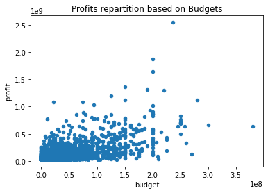

```python
# Here we visualize the repartition profit regarding the budget of each movie

profitable_movies.plot(x="budget", y="profit", kind="scatter", title="Profits repartition based on Budgets");
```

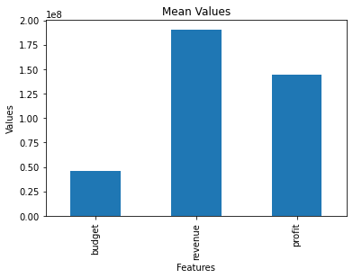

```python
# Here we see mean values of budget, revenue and profit for the most profitable movies

profitable_movies[["budget","revenue","profit"]].mean().plot(x="budget", y="revenue",kind="bar", title="Mean Values");
plt.xlabel("Features")
plt.ylabel("Values")
plt.show()
```

## Conclusions

### Our Findings are :

#### Question 1 :

##### the movies with high revenues:

- have higher budgets
- are not necessary the most popular
- run in meantime 112 minutes
- generate in average 131751100 dollars of profits

#### Question 2 :

##### In 2015:

- the average cost of a high revenue movie was 61304900 dollars
- the most budgetize genre was : **'Action|Adventure|Crime '**

#### Question 3 :

##### The top ten (10) of most profitable movies all time is:

1. Avatar (2009)
2. Star Wars: The Force Awakens (2015)
3. Titanic (1997)
4. Jurassic World (2015)
5. Furious 7 (2015)
6. The Avengers (2012)
7. Harry Potter and the Deathly Hallows: Part 2 (2011)
8. Avengers: Age of Ultron (2015)
9. Frozen (2013)
10. The Net (1995)

### Limitations

###### Eventhough i have focused my work on numerical features, the fact that there so much missing values in some strings columns could limit us in further and more wide Analysis. It would be better to find a way to deal more efficiently with those missing values to help future analysis to be more accurates. Even more, in my work i supposed that the currency used was the ''dollar" but since the actual currency wasn't specified anywhere, it could refere to anything. So to enhance the accuracy of future analysis the unit used for each numerical column must be specified

### Thanks for your Time. Merry Chrismas and Happy New Year